# Analyses statistiques des études Zotovic & Rehazenter

Author

Oussama Abdoun

# Préparation

## Packages

**Voir le code**

```r
library(BayesFactor) # analyses bayésiennes (calcul du Bayes Factor)
library(gtsummary)   # tableaux de résultats statistiques mis en forme
library(DT)          # tableaux interactifs HTML
library(knitr)       # options de rendu du document
library(patchwork)   # assemblages de plusieurs graphiques
library(scales)      # formatage des axes des graphiques
library(ggtext)      # formatage du texte dans les graphiques
library(readxl)      # lire les fichiers Excel
library(tidyverse)   # manipulation et visualisation des données (ggplot2, dplyr…)

# Options globales
options(scipen = 4)          # éviter la notation scientifique sauf si nécessaire
set.seed(42)                 # reproductibilité des analyses stochastiques
```

## Données

**Voir le code**

```r
# ─────────────────────────────────────────────────────────────────────────────
# CHARGEMENT ET PRÉPARATION DES DONNÉES
# ─────────────────────────────────────────────────────────────────────────────

# Lecture du fichier Excel
df_raw <- read_excel("data/consolidated.xlsx")

# Nettoyage
# --- On s'assure que les colonnes catégorielles sont bien des facteurs
df_raw <- df_raw |>
  mutate(
    study     = factor(study),
    treatment = factor(treatment, levels = c("CTRL", "NS"))  # CTRL = référence
  )

# --- On crée un jeu de données "combiné" (les 2 études ensemble)
df_combined <- df_raw |>
  mutate(study = factor("Combined"))

# --- On concatène les 3 jeux (Zotovic, Rehazenter, Combined) dans le même tableau
df_all <- bind_rows(df_raw, df_combined) |>
  mutate(study = factor(study, levels = c("Zotovic", "Rehazenter", "Combined")))

# --- Identification automatique des variables d'outcome (se terminent par "deltaV4V1")
outcome_vars <- names(df_raw) |>
  keep(~ str_detect(.x, "delta"))

# --- On s'assure que les variables d'outcome sont au format numérique
df_all <- df_all |>
  mutate(across(all_of(outcome_vars), as.numeric))

# Les 3 jeux de données à analyser en parallèle
datasets <- list(
  Zotovic    = df_all |> filter(study == "Zotovic"),
  Rehazenter = df_all |> filter(study == "Rehazenter"),
  Combined   = df_all |> filter(study == "Combined")
)
```

## Paramètres d’affichage

**Voir le code**

```r
# Noms lisibles pour l'affichage dans les graphiques et tables
outcome_labels <- c(
  "NFAC_deltaV4V1"          = "NFAC (V4−V1)",
  "10MWT_speed_deltaV4V1"   = "10MWT (V4−V1)",
  "6MWT_dist_deltaV4V1"      = "6MWT (V4−V1)",
  "TUG_deltaV4V1"           = "TUG (V4−V1)",
  "MAS_burden_deltaV4V1"    = "MAS burden (V4−V1)",
  "MRC_total_deltaV4V1"     = "MRC total (V4−V1)"
)

# Couleurs pour les 3 jeux de données (cohérentes dans tous les graphiques)
study_colors <- c(
  "Zotovic"    = "maroon3",   # bleu
  "Rehazenter" = "dodgerblue3",   # orange
  "Combined"   = "grey20"    # vert
)

# Couleurs pour les groupes de traitement
trt_colors <- c("CTRL" = "aquamarine3", "NS" = "coral")
```

## Fonctions d’analyse

**Voir le code**

```r
# ─────────────────────────────────────────────────────────────────────────────
# FONCTIONS D'ANALYSE RÉUTILISABLES
# Ces fonctions seront appelées en boucle pour chaque variable d'outcome.
# ─────────────────────────────────────────────────────────────────────────────

# ── 1. Graphique de distribution (stripchart + boxplot) ──────────────────────
plot_distribution <- function(data, var, label, study_name) {
  # Supprime les lignes avec des valeurs manquantes pour la variable
  d <- data |> filter(!is.na(.data[[var]]))

  ggplot(d, aes(x = treatment, y = .data[[var]], color = treatment, fill = treatment)) +
    # Boxplot transparent (montre quartiles / médiane)
    geom_boxplot(
      alpha = 0.15, width = 0.4,
      outlier.shape = NA    # les points individuels sont affichés séparément
    ) +
    # Points individuels avec un léger décalage horizontal aléatoire (jitter) et un contour blanc
    # pour limiter les effets de superposition
    geom_jitter(
      width = 0.12, size = 3, alpha = 0.8, shape = 21,
      color = "white", stroke = 0.8
    ) +
    # Ligne horizontale en 0 (aucun changement pre-post)
    geom_hline(yintercept = 0, linetype = "dashed", color = "grey50", linewidth = 0.6) +
    scale_color_manual(values = trt_colors) +
    scale_fill_manual(values  = trt_colors) +
    labs(
      title = study_name,
      y     = paste("Δ", label),
      x     = NULL
    ) +
    theme_bw(base_size = 11) +
    theme(
      legend.position = "none",
      plot.title      = element_text(face = "bold", hjust = 0.5,
                                     color = study_colors[study_name]),
      panel.grid.minor = element_blank()
    )
}

# ── 2. T-test non apparié exact ───────────────────────────────────────────────
run_ttest <- function(data, var) {
  # Sépare les 2 groupes en supprimant les NA
  grp_ns   <- data |> filter(treatment == "NS",   !is.na(.data[[var]])) |> pull(.data[[var]])
  grp_ctrl <- data |> filter(treatment == "CTRL",  !is.na(.data[[var]])) |> pull(.data[[var]])

  # t.test exact (var.equal = FALSE = test de Welch, robuste aux variances inégales)
  if (length(grp_ns) >= 2 && length(grp_ctrl) >= 2) {
    t.test(grp_ns, grp_ctrl, var.equal = FALSE)
  } else {
    NULL   # pas assez d'observations
  }
}

# ── 3. Bayes Factor (package BayesFactor) ────────────────────────────────────
run_bf <- function(data, var) {
  # Sépare les 2 groupes en supprimant les NA
  grp_ns   <- data |> filter(treatment == "NS",   !is.na(.data[[var]])) |> pull(.data[[var]])
  grp_ctrl <- data |> filter(treatment == "CTRL",  !is.na(.data[[var]])) |> pull(.data[[var]])

  # ttestBF : test bayésien équivalent au t-test indépendant
  # Prior par défaut (medium : Cauchy, r = 0.707) — hypothèse a priori neutre
  if (length(grp_ns) >= 2 && length(grp_ctrl) >= 2) {
    ttestBF(
      x = grp_ctrl,
      y = grp_ns,
      paired = FALSE,
      rscale = "medium"
    )
  } else {
    NULL   # pas assez d'observations
  }
}

# ── 4. Extraction des résultats sous forme tabulaire ─────────────────────────
extract_results <- function(tt, bf_obj, study_name, n_ns, n_ctrl) {
  # Initialise avec des NA
  res <- tibble(
    Étude       = study_name,
    `n (NS)`    = n_ns,
    `n (CTRL)`  = n_ctrl,
    `Δ moyen (NS−CTRL)` = NA_real_,
    `IC 95% bas` = NA_real_,
    `IC 95% haut`= NA_real_,
    `t`         = NA_real_,
    `ddl`       = NA_real_,
    `p-valeur`  = NA_real_,
    `BF₁₀`      = NA_real_,
  )

  if (!is.null(tt)) {
    res$`Δ moyen (NS−CTRL)` <- tt$estimate[1] - tt$estimate[2]
    res$`IC 95% bas`        <- tt$conf.int[1]
    res$`IC 95% haut`       <- tt$conf.int[2]
    res$`t`                 <- tt$statistic
    res$`ddl`               <- tt$parameter
    res$`p-valeur`          <- tt$p.value
  }

  if (!is.null(bf_obj)) {
    res$`BF₁₀`  <- as.vector(bf_obj)
  }

  res
}
```

# Aperçu des données brutes

Le tableau interactif ci-dessous montre l’ensemble des données. Vous pouvez trier, filtrer et rechercher des valeurs spécifiques.

**Voir le code**

```r
# On affiche les données originales (sans la ligne "Combined" artificielle)
datatable(
  df_raw,
  filter    = "top",          # filtres colonne par colonne en haut du tableau
  rownames  = FALSE,
  extensions = "Buttons",
  options = list(
    dom        = "lfBrtip",   # layout : Buttons, Length, Filter, Row, Table, Info, Pagination
    buttons    = list("csv", "excel", "copy"),   # export CSV / Excel / copie
    pageLength = 15,
    scrollX    = TRUE,        # défilement horizontal si besoin
    columnDefs = list(
      list(className = "dt-center", targets = "_all")
    )
  ),
  caption = "Tableau 1 : Données brutes — toutes études et tous patients."
) |>
  formatRound(columns = outcome_vars, digits = 3) |>
  formatStyle("id_subject",
    `min-width` = "160px"
  ) |>
  formatStyle("treatment",
    backgroundColor = styleEqual(c("CTRL", "NS"), c("aquamarine","coral"))
  ) |>
  formatStyle("study",
    fontWeight = "bold"
  )
```

| study | id_subject | treatment | days_since_stroke | NFAC_deltaV4V1 | 10MWT_speed_deltaV4V1 | 6MWT_dist_deltaV4V1 | TUG_deltaV4V1 | MAS_burden_deltaV4V1 | MRC_total_deltaV4V1 |
| --- | --- | --- | --- | --- | --- | --- | --- | --- | --- |
| Zotovic | 07_NM | CTRL | 44 | 0 | 0.09521444 | 49 | -11 | 0 | 0 |
| Zotovic | 08_DZ | CTRL | 12 | 1 | 0.508701472 | 23 | -1.1 | 0 | 0 |
| Zotovic | 09_DM | CTRL | 44 | 3 | 0.854700855 | 302 | -8.8 | -5 | 15 |
| Zotovic | 10_KI | CTRL | 14 | 2 | -0.016835017 | 126 | -9 | 0 | 8 |
| Zotovic | 11_LJ | CTRL | 17 | 3 | 0.041666667 | 126 | -19 | 0 | 9 |
| Zotovic | 01_BD | NS | 33 | 2 | 0.448717949 | 38 | -10 | -2 | 7 |
| Zotovic | 02_KS | NS | 23 | 3 | 0.66521265 | 155 | -7.9 | -3 | 12 |
| Zotovic | 03_BZ | NS | 34 | 3 | 0.138888889 | 183 | -9.3 | -3 | 8 |
| Zotovic | 05_MT | NS | 150 | 1 | 0.168269231 | 92 | -64.9 | -4 | 0 |
| Zotovic | 06_CV | NS | 36 | 4 | 0.694444444 | 317 | -30.7 | -2 | 12 |

[output cut: 14 more lines]

**Voir le code**

```r
idx_table <- 1
```

# Analyses statistiques

**Voir le code**

```r
# ─────────────────────────────────────────────────────────────────────────────
# BOUCLE PRINCIPALE : génère un onglet par variable d'outcome
# ─────────────────────────────────────────────────────────────────────────────

results_list <- list()   # stocke les résultats tabulaires
plots_dist <- list()     # stocke les graphiques de distribution

# Boucler sur chaque variable d'outcome
for (var in outcome_vars) {

  # Récupérer le libellé lisible de la variable
  label <- outcome_labels[var]

  # ── Analyses pour les 3 jeux de données ─────────────────────────────────
  results_list[[var]] <- list()   # stocke les résultats tabulaires
  plots_dist[[var]] <- list()     # stocke les graphiques de distribution

  for (study_name in names(datasets)) {
    d <- datasets[[study_name]]

    # Tailles des groupes (pour le tableau de résultats)
    n_ns   <- sum(!is.na(d[[var]]) & d$treatment == "NS")
    n_ctrl <- sum(!is.na(d[[var]]) & d$treatment == "CTRL")

    # T-test et Bayes Factor
    tt     <- run_ttest(d, var)
    bf_obj <- run_bf(d, var)

    # Compilation des résultats
    results_list[[var]][[study_name]] <- extract_results(tt, bf_obj, study_name, n_ns, n_ctrl)

    # Graphique de distribution
    plots_dist[[var]][[study_name]] <- plot_distribution(d, var, label, study_name)
  }
}
```

## Distributions NS vs CTRL

**NFAC (V4−V1)**

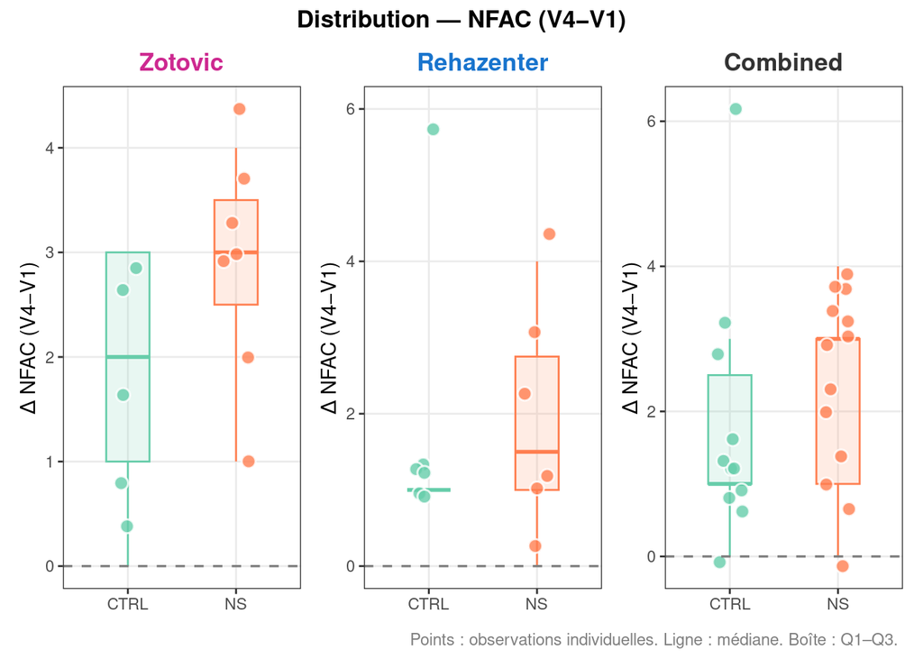

**10MWT (V4−V1)**

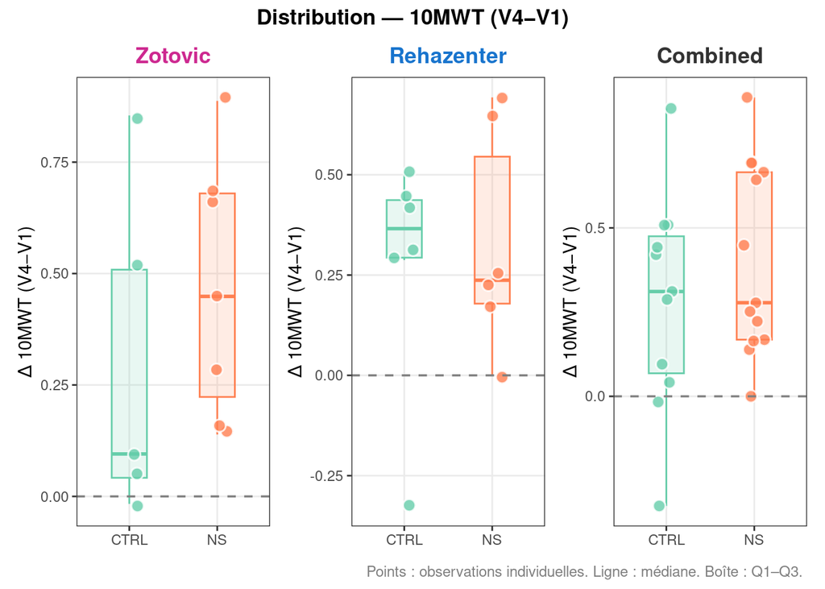

**6MWT (V4−V1)**

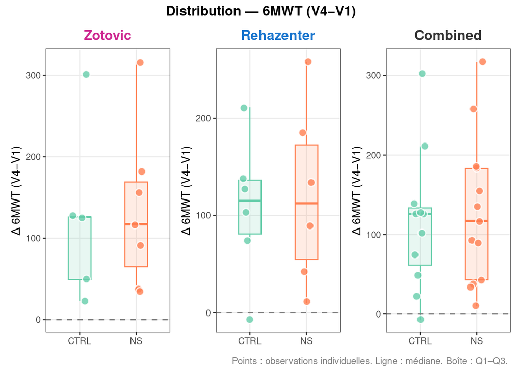

**TUG (V4−V1)**

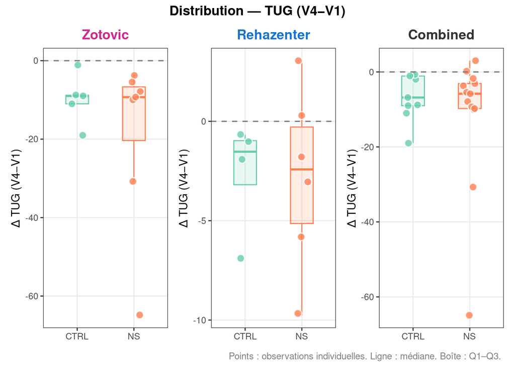

**MAS burden (V4−V1)**

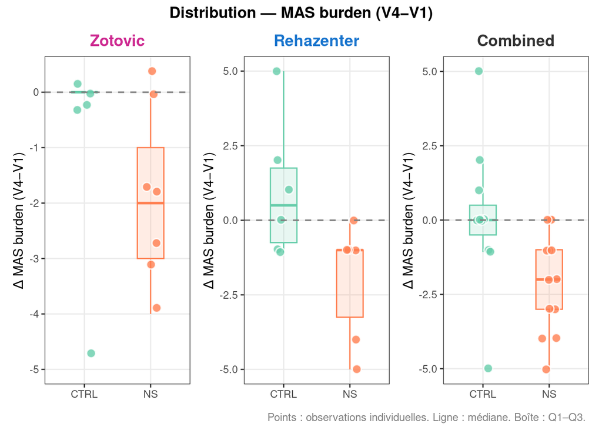

**MRC total (V4−V1)**

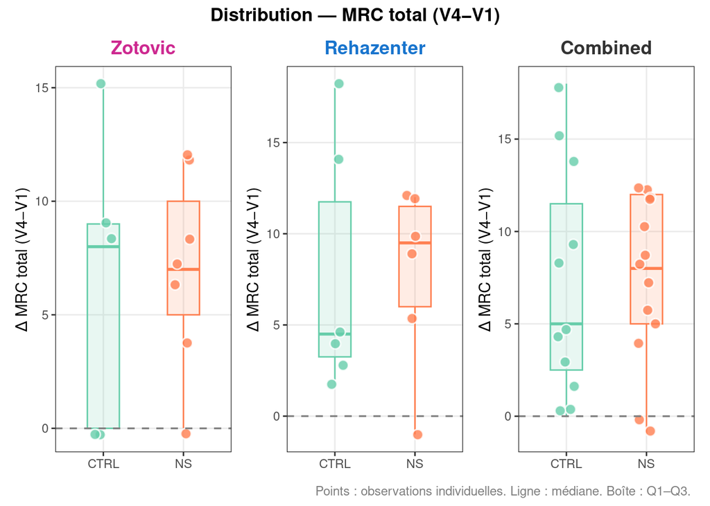

## Résultats statistiques

**NFAC (V4−V1)**

**NoteGuide d’interprétation**

#### T-test de Welch (analyse fréquentiste)

Compare les moyennes de deux groupes indépendants sans supposer que leurs variances sont égales (hypothèse souvent non vérifiable avec de petits échantillons). Il produit :

- Une **valeur p** : probabilité d’observer une différence au moins aussi grande si l’hypothèse nulle était vraie. Seuil conventionnel : p < 0,05. Une valeur élevée ne valide **pas** l’hypothèse nulle.
- Un **intervalle de confiance (IC) à 95 %** de la différence des moyennes. Si l’IC ne contient pas 0, la différence est statistiquement significative.

#### Facteur de Bayes (analyse bayésienne)

Le prior utilisé est une distribution de Cauchy centrée en 0 avec r = 0,707 (prior par défaut de Rouder et al. (2009)), qui encode une incertitude symétrique et raisonnable sur la taille de l’effet.

Le **BF₁₀** (*Bayes Factor*) quantifie le rapport de vraisemblance entre l’hypothèse H₁ (il existe une différence) et H₀ (pas de différence). Kass and Raftery (1995) ont proposé les seuils d’interprétation suivants :

| BF₁₀ | Interprétation |
| --- | --- |
| > 100 | Preuve décisive pour H₁ |
| 10 – 100 | Preuve forte pour H₁ |
| 3 – 10 | Preuve modérée pour H₁ |
| 1 – 3 | Preuve anecdotique pour H₁ |
| 1 | Données non informatives |
| 1 – 1/3 | Preuve anecdotique pour H₀ |
| 1/3 – 1/10 | Preuve modérée pour H₀ |
| 1/10 – 1/100 | Preuve forte pour H₀ |
| < 1/100 | Preuve décisive pour H₀ |

**Note :** Les niveaux de preuve anecdotiques doivent être considérés comme *non conclusifs*.

Tableau 2 — Résultats pour : NFAC (V4−V1)

| Étude | n (NS) | n (CTRL) | Δ moyen (NS−CTRL) | IC 95% bas | IC 95% haut | t | ddl | p-valeur | BF₁₀ |
| --- | --- | --- | --- | --- | --- | --- | --- | --- | --- |
| Zotovic | 7 | 5 | 1.057 | -0.594 | 2.708 | 1.49 | 7.6 | 0.176 | 0.95 |
| Rehazenter | 6 | 6 | 0.000 | -2.321 | 2.321 | 0.00 | 9.1 | 1.000 | 0.47 |
| Combined | 13 | 11 | 0.566 | -0.734 | 1.867 | 0.91 | 19.1 | 0.374 | 0.51 |

**10MWT (V4−V1)**

**NoteGuide d’interprétation**

#### T-test de Welch (analyse fréquentiste)

Compare les moyennes de deux groupes indépendants sans supposer que leurs variances sont égales (hypothèse souvent non vérifiable avec de petits échantillons). Il produit :

- Une **valeur p** : probabilité d’observer une différence au moins aussi grande si l’hypothèse nulle était vraie. Seuil conventionnel : p < 0,05. Une valeur élevée ne valide **pas** l’hypothèse nulle.
- Un **intervalle de confiance (IC) à 95 %** de la différence des moyennes. Si l’IC ne contient pas 0, la différence est statistiquement significative.

#### Facteur de Bayes (analyse bayésienne)

Le prior utilisé est une distribution de Cauchy centrée en 0 avec r = 0,707 (prior par défaut de Rouder et al. (2009)), qui encode une incertitude symétrique et raisonnable sur la taille de l’effet.

Le **BF₁₀** (*Bayes Factor*) quantifie le rapport de vraisemblance entre l’hypothèse H₁ (il existe une différence) et H₀ (pas de différence). Kass and Raftery (1995) ont proposé les seuils d’interprétation suivants :

| BF₁₀ | Interprétation |
| --- | --- |
| > 100 | Preuve décisive pour H₁ |
| 10 – 100 | Preuve forte pour H₁ |
| 3 – 10 | Preuve modérée pour H₁ |
| 1 – 3 | Preuve anecdotique pour H₁ |
| 1 | Données non informatives |
| 1 – 1/3 | Preuve anecdotique pour H₀ |
| 1/3 – 1/10 | Preuve modérée pour H₀ |
| 1/10 – 1/100 | Preuve forte pour H₀ |
| < 1/100 | Preuve décisive pour H₀ |

**Note :** Les niveaux de preuve anecdotiques doivent être considérés comme *non conclusifs*.

Tableau 3 — Résultats pour : 10MWT (V4−V1)

| Étude | n (NS) | n (CTRL) | Δ moyen (NS−CTRL) | IC 95% bas | IC 95% haut | t | ddl | p-valeur | BF₁₀ |
| --- | --- | --- | --- | --- | --- | --- | --- | --- | --- |
| Zotovic | 7 | 5 | 0.172 | -0.297 | 0.641 | 0.86 | 7.3 | 0.417 | 0.61 |
| Rehazenter | 6 | 6 | 0.055 | -0.320 | 0.430 | 0.33 | 9.9 | 0.750 | 0.48 |
| Combined | 13 | 11 | 0.120 | -0.139 | 0.379 | 0.97 | 20.1 | 0.345 | 0.53 |

**6MWT (V4−V1)**

**NoteGuide d’interprétation**

#### T-test de Welch (analyse fréquentiste)

Compare les moyennes de deux groupes indépendants sans supposer que leurs variances sont égales (hypothèse souvent non vérifiable avec de petits échantillons). Il produit :

- Une **valeur p** : probabilité d’observer une différence au moins aussi grande si l’hypothèse nulle était vraie. Seuil conventionnel : p < 0,05. Une valeur élevée ne valide **pas** l’hypothèse nulle.
- Un **intervalle de confiance (IC) à 95 %** de la différence des moyennes. Si l’IC ne contient pas 0, la différence est statistiquement significative.

#### Facteur de Bayes (analyse bayésienne)

Le prior utilisé est une distribution de Cauchy centrée en 0 avec r = 0,707 (prior par défaut de Rouder et al. (2009)), qui encode une incertitude symétrique et raisonnable sur la taille de l’effet.

Le **BF₁₀** (*Bayes Factor*) quantifie le rapport de vraisemblance entre l’hypothèse H₁ (il existe une différence) et H₀ (pas de différence). Kass and Raftery (1995) ont proposé les seuils d’interprétation suivants :

| BF₁₀ | Interprétation |
| --- | --- |
| > 100 | Preuve décisive pour H₁ |
| 10 – 100 | Preuve forte pour H₁ |
| 3 – 10 | Preuve modérée pour H₁ |
| 1 – 3 | Preuve anecdotique pour H₁ |
| 1 | Données non informatives |
| 1 – 1/3 | Preuve anecdotique pour H₀ |
| 1/3 – 1/10 | Preuve modérée pour H₀ |
| 1/10 – 1/100 | Preuve forte pour H₀ |
| < 1/100 | Preuve décisive pour H₀ |

**Note :** Les niveaux de preuve anecdotiques doivent être considérés comme *non conclusifs*.

Tableau 4 — Résultats pour : 6MWT (V4−V1)

| Étude | n (NS) | n (CTRL) | Δ moyen (NS−CTRL) | IC 95% bas | IC 95% haut | t | ddl | p-valeur | BF₁₀ |
| --- | --- | --- | --- | --- | --- | --- | --- | --- | --- |
| Zotovic | 7 | 5 | 8.371 | -132.415 | 149.158 | 0.14 | 8.2 | 0.895 | 0.47 |
| Rehazenter | 6 | 6 | 12.333 | -95.168 | 119.834 | 0.26 | 9.5 | 0.802 | 0.48 |
| Combined | 13 | 11 | 11.657 | -63.905 | 87.220 | 0.32 | 21.7 | 0.752 | 0.39 |

**TUG (V4−V1)**

**NoteGuide d’interprétation**

#### T-test de Welch (analyse fréquentiste)

Compare les moyennes de deux groupes indépendants sans supposer que leurs variances sont égales (hypothèse souvent non vérifiable avec de petits échantillons). Il produit :

- Une **valeur p** : probabilité d’observer une différence au moins aussi grande si l’hypothèse nulle était vraie. Seuil conventionnel : p < 0,05. Une valeur élevée ne valide **pas** l’hypothèse nulle.
- Un **intervalle de confiance (IC) à 95 %** de la différence des moyennes. Si l’IC ne contient pas 0, la différence est statistiquement significative.

#### Facteur de Bayes (analyse bayésienne)

Le prior utilisé est une distribution de Cauchy centrée en 0 avec r = 0,707 (prior par défaut de Rouder et al. (2009)), qui encode une incertitude symétrique et raisonnable sur la taille de l’effet.

Le **BF₁₀** (*Bayes Factor*) quantifie le rapport de vraisemblance entre l’hypothèse H₁ (il existe une différence) et H₀ (pas de différence). Kass and Raftery (1995) ont proposé les seuils d’interprétation suivants :

| BF₁₀ | Interprétation |
| --- | --- |
| > 100 | Preuve décisive pour H₁ |
| 10 – 100 | Preuve forte pour H₁ |
| 3 – 10 | Preuve modérée pour H₁ |
| 1 – 3 | Preuve anecdotique pour H₁ |
| 1 | Données non informatives |
| 1 – 1/3 | Preuve anecdotique pour H₀ |
| 1/3 – 1/10 | Preuve modérée pour H₀ |
| 1/10 – 1/100 | Preuve forte pour H₀ |
| < 1/100 | Preuve décisive pour H₀ |

**Note :** Les niveaux de preuve anecdotiques doivent être considérés comme *non conclusifs*.

Tableau 5 — Résultats pour : TUG (V4−V1)

| Étude | n (NS) | n (CTRL) | Δ moyen (NS−CTRL) | IC 95% bas | IC 95% haut | t | ddl | p-valeur | BF₁₀ |
| --- | --- | --- | --- | --- | --- | --- | --- | --- | --- |
| Zotovic | 7 | 5 | -9.069 | -29.851 | 11.714 | -1.02 | 7.3 | 0.339 | 0.60 |
| Rehazenter | 6 | 4 | -0.237 | -5.598 | 5.123 | -0.10 | 8.0 | 0.921 | 0.50 |
| Combined | 13 | 9 | -4.871 | -16.323 | 6.582 | -0.90 | 15.7 | 0.380 | 0.48 |

**MAS burden (V4−V1)**

**NoteGuide d’interprétation**

#### T-test de Welch (analyse fréquentiste)

Compare les moyennes de deux groupes indépendants sans supposer que leurs variances sont égales (hypothèse souvent non vérifiable avec de petits échantillons). Il produit :

- Une **valeur p** : probabilité d’observer une différence au moins aussi grande si l’hypothèse nulle était vraie. Seuil conventionnel : p < 0,05. Une valeur élevée ne valide **pas** l’hypothèse nulle.
- Un **intervalle de confiance (IC) à 95 %** de la différence des moyennes. Si l’IC ne contient pas 0, la différence est statistiquement significative.

#### Facteur de Bayes (analyse bayésienne)

Le prior utilisé est une distribution de Cauchy centrée en 0 avec r = 0,707 (prior par défaut de Rouder et al. (2009)), qui encode une incertitude symétrique et raisonnable sur la taille de l’effet.

Le **BF₁₀** (*Bayes Factor*) quantifie le rapport de vraisemblance entre l’hypothèse H₁ (il existe une différence) et H₀ (pas de différence). Kass and Raftery (1995) ont proposé les seuils d’interprétation suivants :

| BF₁₀ | Interprétation |
| --- | --- |
| > 100 | Preuve décisive pour H₁ |
| 10 – 100 | Preuve forte pour H₁ |
| 3 – 10 | Preuve modérée pour H₁ |
| 1 – 3 | Preuve anecdotique pour H₁ |
| 1 | Données non informatives |
| 1 – 1/3 | Preuve anecdotique pour H₀ |
| 1/3 – 1/10 | Preuve modérée pour H₀ |
| 1/10 – 1/100 | Preuve forte pour H₀ |
| < 1/100 | Preuve décisive pour H₀ |

**Note :** Les niveaux de preuve anecdotiques doivent être considérés comme *non conclusifs*.

Tableau 6 — Résultats pour : MAS burden (V4−V1)

| Étude | n (NS) | n (CTRL) | Δ moyen (NS−CTRL) | IC 95% bas | IC 95% haut | t | ddl | p-valeur | BF₁₀ |
| --- | --- | --- | --- | --- | --- | --- | --- | --- | --- |
| Zotovic | 7 | 5 | -1.000 | -3.762 | 1.762 | -0.87 | 6.6 | 0.417 | 0.62 |
| Rehazenter | 6 | 6 | -2.987 | -5.763 | -0.212 | -2.40 | 9.8 | 0.037 | 2.19 |
| Combined | 13 | 11 | -2.084 | -3.890 | -0.277 | -2.43 | 17.6 | 0.026 | 3.08 |

**MRC total (V4−V1)**

**NoteGuide d’interprétation**

#### T-test de Welch (analyse fréquentiste)

Compare les moyennes de deux groupes indépendants sans supposer que leurs variances sont égales (hypothèse souvent non vérifiable avec de petits échantillons). Il produit :

- Une **valeur p** : probabilité d’observer une différence au moins aussi grande si l’hypothèse nulle était vraie. Seuil conventionnel : p < 0,05. Une valeur élevée ne valide **pas** l’hypothèse nulle.
- Un **intervalle de confiance (IC) à 95 %** de la différence des moyennes. Si l’IC ne contient pas 0, la différence est statistiquement significative.

#### Facteur de Bayes (analyse bayésienne)

Le prior utilisé est une distribution de Cauchy centrée en 0 avec r = 0,707 (prior par défaut de Rouder et al. (2009)), qui encode une incertitude symétrique et raisonnable sur la taille de l’effet.

Le **BF₁₀** (*Bayes Factor*) quantifie le rapport de vraisemblance entre l’hypothèse H₁ (il existe une différence) et H₀ (pas de différence). Kass and Raftery (1995) ont proposé les seuils d’interprétation suivants :

| BF₁₀ | Interprétation |
| --- | --- |
| > 100 | Preuve décisive pour H₁ |
| 10 – 100 | Preuve forte pour H₁ |
| 3 – 10 | Preuve modérée pour H₁ |
| 1 – 3 | Preuve anecdotique pour H₁ |
| 1 | Données non informatives |
| 1 – 1/3 | Preuve anecdotique pour H₀ |
| 1/3 – 1/10 | Preuve modérée pour H₀ |
| 1/10 – 1/100 | Preuve forte pour H₀ |
| < 1/100 | Preuve décisive pour H₀ |

**Note :** Les niveaux de preuve anecdotiques doivent être considérés comme *non conclusifs*.

Tableau 7 — Résultats pour : MRC total (V4−V1)

| Étude | n (NS) | n (CTRL) | Δ moyen (NS−CTRL) | IC 95% bas | IC 95% haut | t | ddl | p-valeur | BF₁₀ |
| --- | --- | --- | --- | --- | --- | --- | --- | --- | --- |
| Zotovic | 7 | 5 | 0.600 | -7.322 | 8.522 | 0.18 | 6.5 | 0.861 | 0.48 |
| Rehazenter | 6 | 6 | 0.167 | -7.500 | 7.834 | 0.05 | 9.3 | 0.962 | 0.47 |
| Combined | 13 | 11 | 0.294 | -4.450 | 5.037 | 0.13 | 17.7 | 0.898 | 0.38 |

## Synthèse graphique des résultats

**NFAC (V4−V1)**

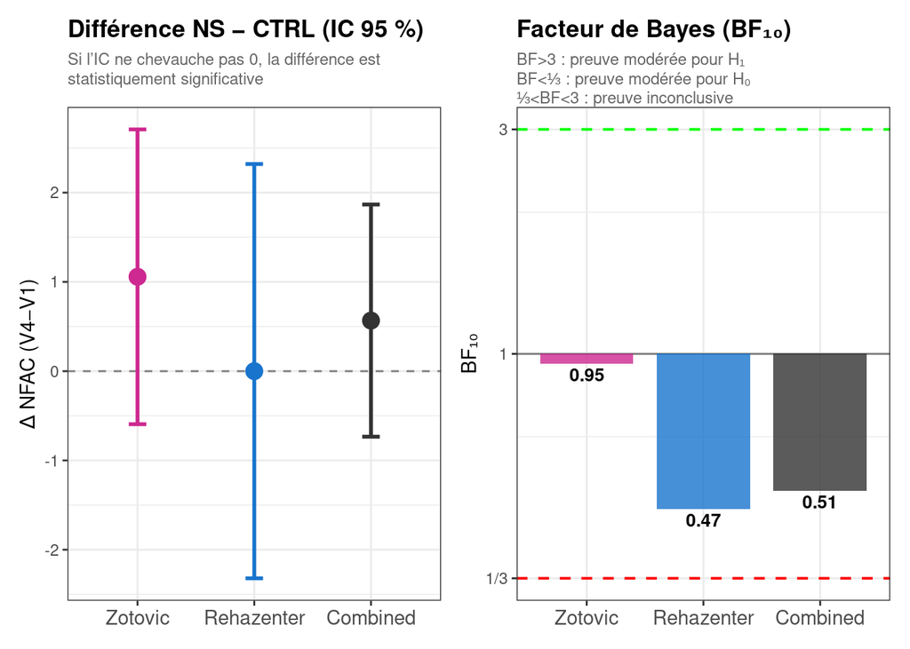

**10MWT (V4−V1)**

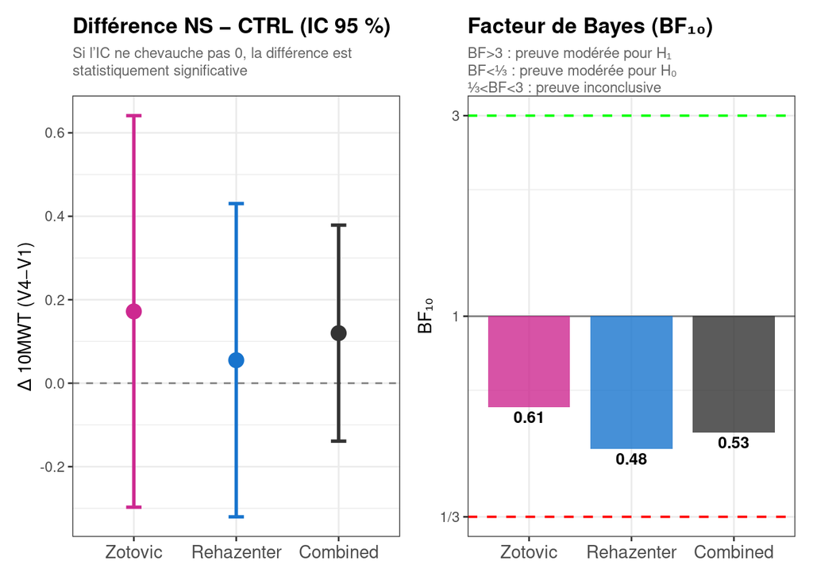

**6MWT (V4−V1)**

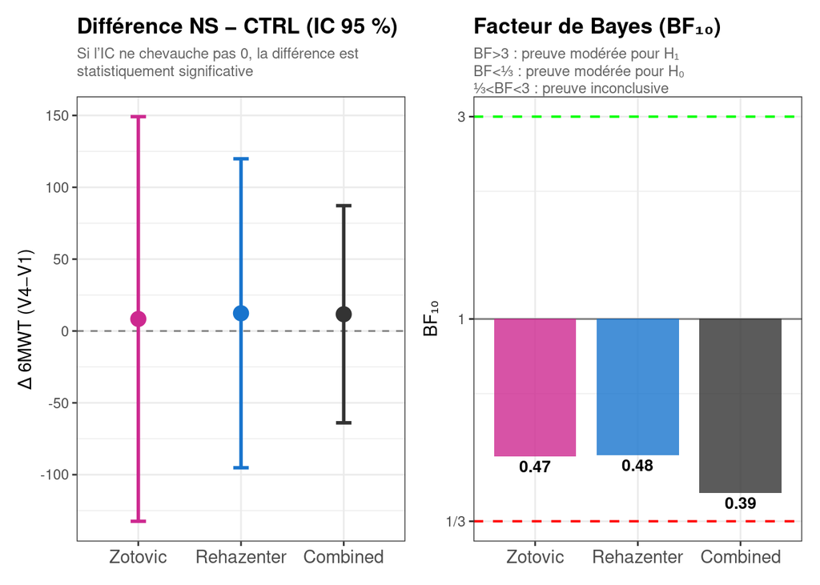

**TUG (V4−V1)**

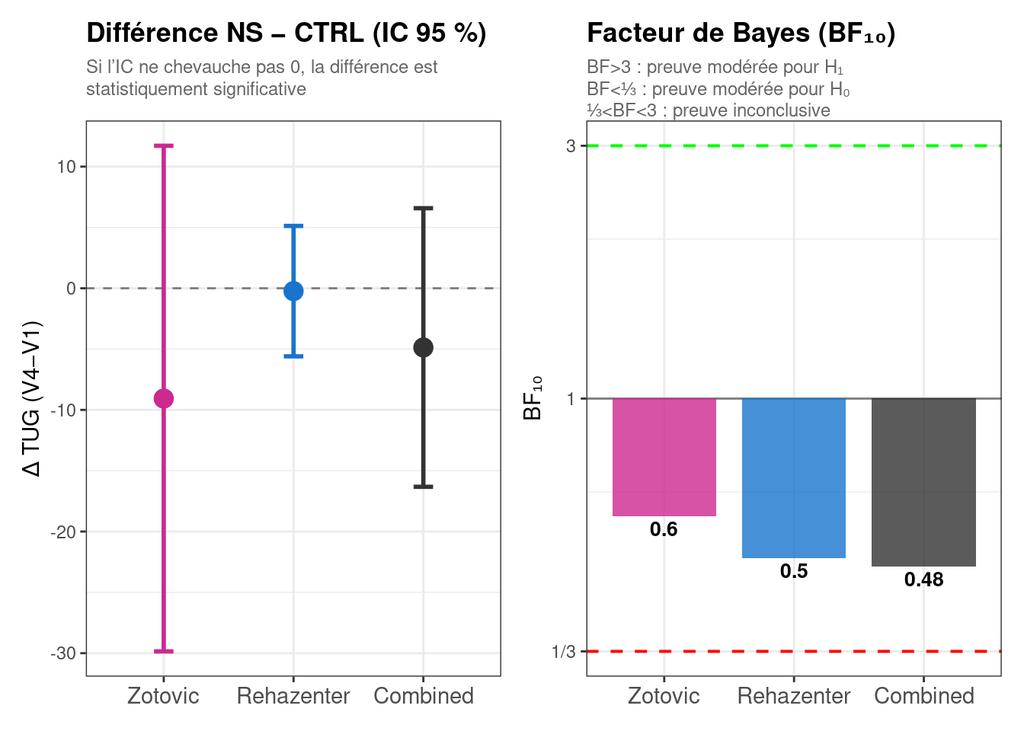

**MAS burden (V4−V1)**

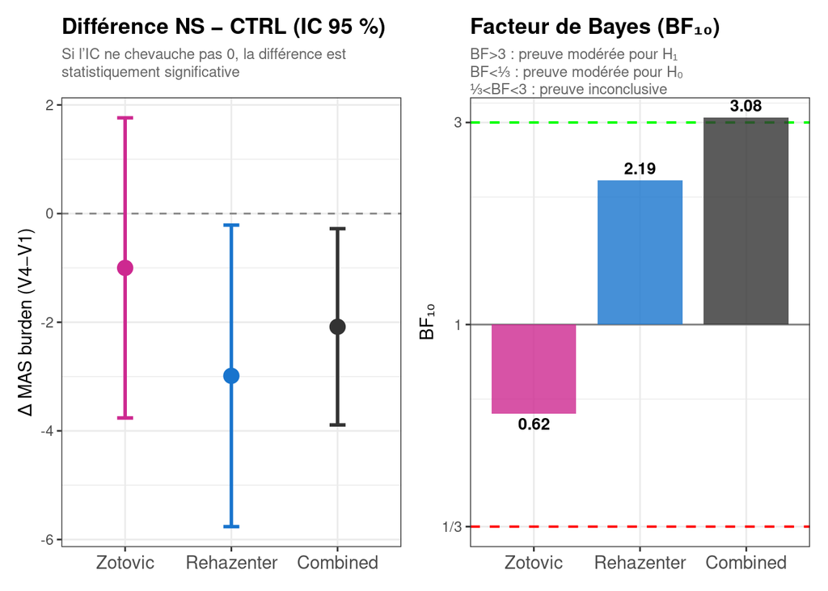

**MRC total (V4−V1)**

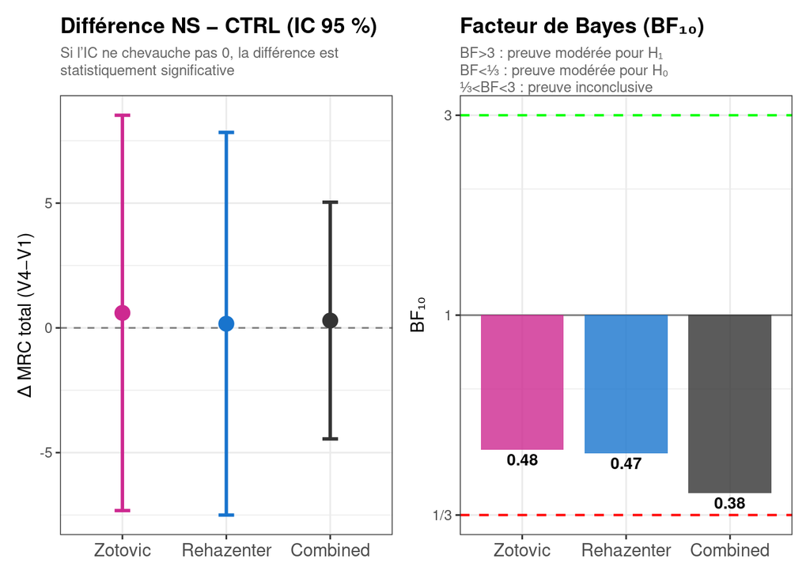

# Références

Kass, Robert E., and Adrian E. Raftery. 1995. “Bayes Factors.” *Journal of the American Statistical Association* 90 (430): 773–95. https://doi.org/10.2307/2291091.

Rouder, Jeffrey N., Paul L. Speckman, Dongchu Sun, Richard D. Morey, and Geoffrey Iverson. 2009. “Bayesian t Tests for Accepting and Rejecting the Null Hypothesis.” *Psychonomic Bulletin & Review* 16 (2): 225–37. https://doi.org/10.3758/PBR.16.2.225.